# KD Practicum 1.1

## Fundamentals review

You might not have any experience with R but, in principle, the same rules apply to other programming languages, such as Python. Let’s start with reviewing fundamentals.

What does the computer translate into when you type `x = 1` into the console? How does an interpreter know where and when to look for `x` and how to evaluate code such as `x<5`? And what output value should `x<5`evaluate into?

We shall start with understanding of the concepts of **statements**, **expressions**, **predicates** and **binding basics (aka association rules)** before moving to the chapter dedicated to basic data types and structures.

### Statements vs. expressions

R is at heart functional programming language that considers computation as the evaluation of mathematical functions — which are a special case of **expressions**. An **expression** is a combination of values and functions that are put together and interpreted to create a new value, as opposed to a **statement** which is just a standalone unit of execution that doesn’t return anything (such as `print()`).

### Arithmetic operations

Technically, every expression is a statement when it’s defined, Let’s consider some basic expressions by investigating how R can be turned into a mathematical calculator. R can handle most simple types of math operators:

- `+` Addition, e.g. `x + y`
- `-` Subtraction
- `*` Multiplication
- `/` Division
- `^` or `**` Exponentiation

The simplest expression is made by combining two values with a math operator (which makes an *infix* function, BTW). Exponentiation has the highest priority, followed by division, multiplication, subtraction and addition. Expressions are evaluated from left to right, but priority can be adjusted by using round brackets.

```r
5+1
```

```
## [1] 6
```

```r
2*(5+1)
```

```
## [1] 12
```

To build expressions, you are not limited to elementary math operations, but feel free to explore other standard math functions loaded within the base R environment. For example, let’s compute the natural logarithm of $\pi$.

```r
log(pi)
```

```
## [1] 1.14473
```

### Logical operators

An important feature of R is the ability to use logic when creating expressions. This is not unique to R as all programming languages can do this, but it is extremely useful when working with data. The standard set of logical operators in R include operators of two kinds: **relational operators** and **pure** **logical operators**.

| Operator | Description | Type |
| --- | --- | --- |
| `<` | Less than | Relational |
| `>` | Greater than | Relational |
| `<=` | Less than or equal to | Relational |
| `>=` | Greater than or equal to | Relational |
| `==` | Exactly equal to | Relational |
| `!=` | Not equal to | Relational |
| `!a` | Not `a` | Logical |
| `a & b` | `a` AND `b` | Logical |
| `a \| b` | `a` OR `b` | Logical |

The **logical operators** are often used to help create a test expression that controls program flow. This type of expression is also known as a Boolean expression because they create a Boolean answer or value when evaluated.

The **relational operators** are use to reason about truth of a given expression — say we ask whether 2<5 is true or if 2 equals to 5 — which is true in the former case and false in the latter.

```r
2<5 ; 2 == 5
```

```
## [1] TRUE
```

```
## [1] FALSE
```

Relational operators are key components of **predicates** — functions that take an input and an expression and return single TRUE or FALSE after evaluating the expression.

Predicate behavior can be serialized by function wrappers such as `is.na()` and subsequently used for set restriction operations on vectors and data frames.

Let’s examine the following example: say, vector `a` contains integers 1 to 12. If we wanted to know where `a>9`, we would expect to see the values 10 11 12. Hence, the condition `a>9` will be evaluated `FALSE` for the first nine vector elements and `TRUE` for the last three elements. The property of predicates is often used for filtering of `a` using single square bracket operator as follows `a[a<5]`. But more on that later.

### Special operators

There are other operators that we will use that are not necessarily mathematical in nature but they are key for the use of R.

| Description | R symbol | Example |
| --- | --- | --- |
| Comment | `#` | # This is a comment |
| Assignment | `<-` or `=` | x `<-` 5 or x `=` 5 |
| Super assignment | `<<-` | x `<<-` 5 |
| Concatenation operator | `c` | c(1,2,3) |
| Modular | `%%` | 25 `%%` 6 |
| Sequence operator | `:` | 1 `:` 3 |
| Boolean inclusion | `%in%` | 2 `%in%` 1:10 |
| Pipe | `%>%` | 1:10 `%>%` +2 |

More of the advanced special operators will emerge when we explore the magrittr package. For now, let’s explore how the **assignment operator** is used.

### Binding basics

Consider this code: `x <- c(1,2,3)`. It’s easy to read it as: “create an object named `'x'`, containing the values 1, 2, and 3”. Unfortunately, that’s a simplification that will lead to inaccurate predictions about what R is actually doing behind the scenes. It’s more accurate to say that this code is doing two things:

- It’s creating an object, a vector of values `c(1,2,3)`.
- And it’s binding that object to name `x`.

The vector object has initially no name. It can be assessed through its memory address 0x74b. In case you are interested, the `tracemem()` function from the base package can reveal its accession ID.

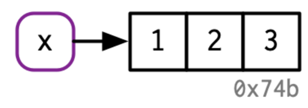

On the scheme above, the name, `x`, is drawn with a rounded rectangle. It has an arrow that points to (or binds) the value, the vector c(1, 2, 3). The arrow points in opposite direction to the assignment arrow: `<-` creates a binding from the name on the left-hand side to the object on the right-hand side.

### Copy-on-modify

Let’s bind `x` and `y` to the same underlying value and then modify `y`.

```r
# Create an integer vector object and name it x.
x <- c(1, 2, 3)
# Double-bind c(1, 2, 3) to names x and y.
y <- x
# Modify y by changing the value of the third element to 4.
y[[3]] <- 4
x ; y # See what happens...
```

```
## [1] 1 2 3
```

```
## [1] 1 2 4
```

Modifying `y` clearly didn’t modify `x`. So what happened to the shared binding? While the value associated with `y` changed, the original object did not. Instead, R created a new object with one value changed, then rebound `y` to that object.

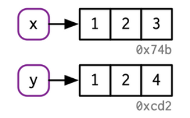

This behavior is called **copy-on-modify**. Understanding it will radically improve your intuition about the performance of R code. A related way to describe this behavior is to say that R objects are unchangeable, or immutable.

You can see when an object gets copied with the help of `base::tracemem()`. Once you call that function with an object, you’ll get the object’s current address.

```r
# Print memory addresses of objects x and y.
tracemem(x) ; tracemem(y)
```

```
## [1] "<00000275F5153C08>"
```

```
## [1] "<00000275F51F15B8>"
```

### Modify-in-place

As we’ve seen above, modifying an R object usually creates a copy. There are two exceptions:

- **Objects with a single binding** get a special performance optimization.
- **Environments**, a special type of object, are always modified in place.

Thus, when it comes to bindings, R can currently only count 0, 1, or many. That means that if an object has two bindings, and one goes away, the reference count does not go back to 1: one less than many is still many. In turn, this means that R will make copies when it sometimes doesn’t need to.

### Exercises

**1.** In some cases, the boundary between expressions and statements is rather blurry. Consider functions and lists — which are recursive data structures in R, which can contain any element type at any position, even list themselves. Are they expressions or statements?

**Answer:** Lists are considered expressions because they have looping constructs and therefore also *do something*. Functions are made by statements when defined but became expressions when they are evaluated.

```r
a <- 1:10 # 1.
b <- a # 2.
a[2] <- 4 # 3.
c <- b # 4.
d <- 1:10 # 5.
```